# Multi-Path Stepwise Selection with AIC

Final Project: STAT 7020

Michael Asante Ofosu, Mohammad Al Srayheen, Soroosh Alavi

2025-12-05

# GitHub Repository Information

**Repository Name:** `multipathaic`  
**Organization:** R-4-Data-Science  
**Repository Link:** https://github.com/R-4-Data-Science/Final_Project_multipathaic

**Installation:**

```r
# Install from GitHub
remotes::install_github("R-4-Data-Science/Final_Project_multipathaic")
```

This project implements a novel multi-path forward selection algorithm with resampling-based stability analysis and plausible model identification. Unlike traditional stepwise selection that follows a single path, **multipathaic** explores multiple near-optimal paths simultaneously, providing:

1. **Multi-Path Forward Selection**: Branching exploration of variable combinations using AIC
2. **Resampling Stability**: Bootstrap-based assessment of variable importance
3. **Plausible Model Sets**: Identification of models that are both statistically sound and stable

The package supports both **linear regression** (Gaussian) and **logistic regression** (Binomial) families.

# 1. Package Overview

## 1.1 Core Functions

| Function | Purpose |
| --- | --- |
| `build_paths()` | Multi-path forward selection using AIC |
| `stability()` | Resampling-based variable stability analysis |
| `plausible_models()` | Filter models by AIC and average stability |
| `confusion_metrics()` | Confusion matrix metrics for classification |

## 1.2 Visualization Functions

The package includes multiple plotting functions for publication-quality figures:

**Main Plotting Functions:** - `plot_aic_by_step()` - AIC evolution across selection steps - `plot_stability()` - Variable stability bar chart - `plot_variable_heatmap()` - Variable co-occurrence heatmap - `plot_model_tree()` - Visual model exploration tree - `plot_model_dashboard()` - Four-panel summary dashboard (requires 3 arguments)

**Additional Visualizations:** - Custom importance plots created with base R graphics - Flexible plotting using ggplot2 and base R

**All plotting functions support customization** for publication-quality figures.

# 2. Algorithm Description

## 2.1 Multi-Path Forward Selection

**Intuition:** Instead of greedily selecting one “best” variable at each step, explore multiple promising paths simultaneously.

**Algorithm:**

1. **Initialize:** Start with the empty model (intercept only)
2. **For each step k = 1 to K:**
   - From every current model, try adding each unused variable
   - Compute AIC for each candidate child model
   - For each parent, keep children within `delta` of parent’s best AIC
   - Only keep children that improve parent’s AIC by at least `eps`
   - Deduplicate models with identical variable sets
   - If too many models, keep best `L` by AIC
3. **Output:** A forest of models organized by selection step

**Key Parameters:** - `K`: Maximum number of variables to select - `eps`: Minimum AIC improvement required (controls greediness) - `delta`: AIC tolerance for branching (controls exploration) - `L`: Maximum models to retain per step (computational constraint)

## 2.2 Stability Analysis via Resampling

**Intuition:** Stable variables appear consistently across many resampled datasets.

**Algorithm:**

1. **For each bootstrap sample b = 1 to B:**
   - Draw bootstrap or subsample from data
   - Run `build_paths()` on resampled data
   - For each variable j, compute proportion of models containing j: $z_j^{(b)}$
2. **Aggregate across resamples:**
   - $\pi_j = \frac{1}{B}\sum_{b=1}^{B} z_j^{(b)}$
3. **Output:** Stability score $\pi_j \in [0,1]$ for each variable

**Interpretation:** $\pi_j$ represents the expected proportion of models that include variable j.

## 2.3 Plausible Model Selection

**Intuition:** Good models should be both statistically competitive (low AIC) and built from stable variables.

**Algorithm:**

1. Gather all unique models from the multi-path forest
2. **AIC Filter:** Keep models with $\text{AIC} \leq \text{AIC}_{\min} + \Delta$
3. **Stability Filter:** For each model S, compute mean stability:
   $$\bar{\pi}(S) =
   \frac{1}{|S|}\sum_{j \in S}\pi_j$$
   Keep models with $\bar{\pi}(S) \geq \tau$
4. **(Optional)** Remove near-duplicates using Jaccard similarity
5. **Output:** Final set of plausible models

# 3. Demonstrations with Base R

Before demonstrating the package, we show the basic concepts using base R.

## 3.1 Linear Regression Example (Gaussian Family)

### 3.1.1 Data Generation

```r
set.seed(1)
n <- 120  # Number of observations
p <- 8    # Number of predictors

# Generate predictors from standard normal
X <- matrix(rnorm(n * p), n, p)

# True coefficient vector (sparse: only 3 non-zero)
beta_true <- c(2, -1.5, 0, 0, 1, rep(0, p - 5))

# Generate response with Gaussian noise
y <- X %*% beta_true + rnorm(n, sd = 1)

# Create data frame
colnames(X) <- paste0("x", 1:p)
df_linear <- as.data.frame(cbind(y, X))

# Display first few rows
head(df_linear)
```

|  | V1 | x1 | x2 | x3 | x4 | x5 | x6 | x7 | x8 |
| --- | --- | --- | --- | --- | --- | --- | --- | --- | --- |
| 1 | -1.646333 | -0.6264538 | -0.5059575 | 0.7073107 | -2.5923277 | -0.3572989 | -0.3410670 | 0.48934096 | 2.0057186 |
| 2 | -2.814041 | 0.1836433 | 1.3430388 | 1.0341077 | 1.3140022 | -1.1468141 | 1.5024245 | -0.77891030 | -2.0705715 |
| 3 | -4.381234 | -0.8356286 | -0.2145794 | 0.2234804 | -0.6355430 | -0.5174205 | 0.5283077 | 1.74355935 | 3.0557424 |
| 4 | 5.308725 | 1.5952808 | -0.1795565 | -0.8787076 | -0.4299788 | -0.3621238 | 0.5421914 | -0.07838729 | -0.2613506 |
| 5 | 1.671094 | 0.3295078 | -0.1001907 | 1.1629646 | -0.1693183 | 2.3505543 | -0.1366734 | -0.97555379 | -0.4543933 |
| 6 | -1.424157 | -0.8204684 | 0.7126663 | -2.0001649 | 0.6122182 | 2.4465314 | -1.1367339 | 0.07065982 | 0.1575606 |

### 3.1.2 Single-Step Forward Selection Comparison

```r
# Fit empty model (intercept only)
fit_empty <- lm(y ~ 1, data = df_linear)
aic_empty <- AIC(fit_empty)

print(paste("Empty Model AIC:", round(aic_empty, 2)))
```

```
## [1] "Empty Model AIC: 600.67"
```

```r
# Try adding each variable individually
candidates <- lapply(1:p, function(j) {
  formula_str <- paste0("y ~ ", colnames(X)[j])
  lm(as.formula(formula_str), data = df_linear)
})

# Compute AIC for each candidate
aics_step1 <- sapply(candidates, AIC)

# Create results table
results_step1 <- data.frame(
  variable = colnames(X),
  AIC = aics_step1,
  AIC_improvement = aic_empty - aics_step1
)

# Sort by AIC (best to worst)
results_step1 <- results_step1[order(results_step1$AIC), ]

# Display top 5 candidates
print("Top 5 Variables by AIC:")
```

```
## [1] "Top 5 Variables by AIC:"
```

```r
print(results_step1[1:5, ], row.names = FALSE)
```

```
##  variable      AIC AIC_improvement
##        x1 535.5318       65.134391
##        x2 556.3635       44.302655
##        x5 581.5423       19.123871
##        x3 596.4350        4.231176
##        x7 599.4055        1.260657
```

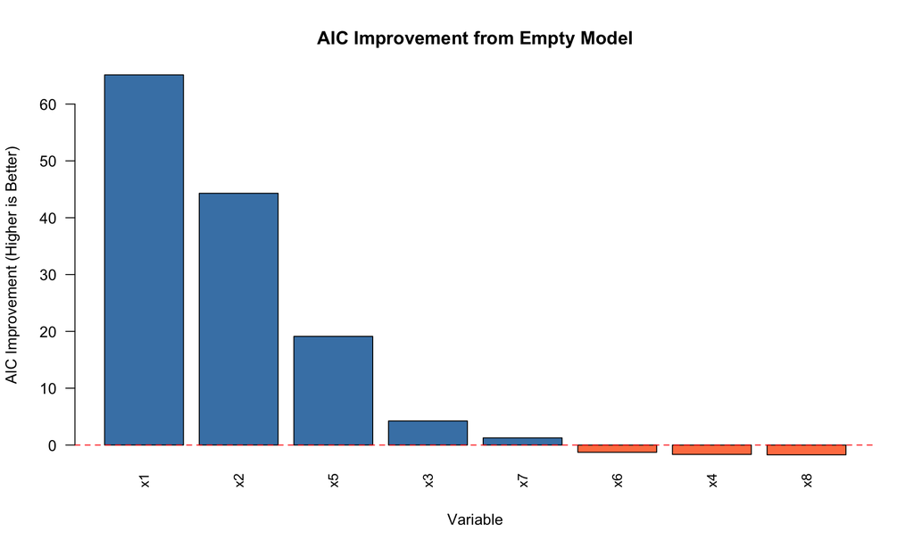

```r
# Visualize AIC comparison
barplot(
  results_step1$AIC_improvement[order(-results_step1$AIC_improvement)],
  names.arg = results_step1$variable[order(-results_step1$AIC_improvement)],
  col = ifelse(results_step1$AIC_improvement[order(-results_step1$AIC_improvement)] > 0,
               "steelblue", "coral"),
  main = "AIC Improvement from Empty Model",
  ylab = "AIC Improvement (Higher is Better)",
  xlab = "Variable",
  las = 2,
  cex.names = 0.9
)
abline(h = 0, lty = 2, col = "red")
```

**Interpretation:** - Variables **x1** and **x2** provide the largest AIC improvements - These correspond to the true non-zero coefficients (β₁ = 2, β₂ = -1.5) - Variable **x5** (β₅ = 1) also improves AIC substantially - Variables x3, x4, x6, x7, x8 (all βⱼ = 0) provide minimal improvement

## 3.2 Logistic Regression Example (Binomial Family)

### 3.2.1 Data Generation

```r
set.seed(2)
n <- 200  # Number of observations
p <- 6    # Number of predictors

# Generate predictors
X_logistic <- matrix(rnorm(n * p), n, p)

# True linear predictor (only 3 variables matter)
linpred <- 1.2 * X_logistic[, 1] - 1.0 * X_logistic[, 2] + 0.8 * X_logistic[, 5]

# Generate binary response via logistic link
prob <- 1 / (1 + exp(-linpred))
y_binary <- rbinom(n, 1, prob)

# Create data frame
colnames(X_logistic) <- paste0("x", 1:p)
df_logistic <- as.data.frame(cbind(y = y_binary, X_logistic))

# Summary statistics
print("Response Variable Summary:")
```

```
## [1] "Response Variable Summary:"
```

```r
print(paste("Class 0:", sum(y_binary == 0), "observations"))
```

```
## [1] "Class 0: 109 observations"
```

```r
print(paste("Class 1:", sum(y_binary == 1), "observations"))
```

```
## [1] "Class 1: 91 observations"
```

```r
print(paste("Prevalence:", round(mean(y_binary), 3)))
```

```
## [1] "Prevalence: 0.455"
```

```r
head(df_logistic)
```

|  | y | x1 | x2 | x3 | x4 | x5 | x6 |
| --- | --- | --- | --- | --- | --- | --- | --- |
| 1 | 0 | -0.89691455 | 0.2979836 | -0.2140756 | -1.1150718 | -0.6290441 | 0.46620043 |
| 2 | 0 | 0.18484918 | -1.0195522 | -2.7218162 | -0.1142184 | -2.2743445 | 0.95466641 |
| 3 | 0 | 1.58784533 | 2.8708974 | -1.0142618 | -0.8946214 | 0.3349372 | -0.94720635 |
| 4 | 0 | -1.13037567 | 0.2187100 | -0.8291451 | -0.6540889 | -0.2136880 | 0.03856309 |
| 5 | 1 | -0.08025176 | -0.9665543 | 0.8577089 | 1.1787163 | -0.0315424 | -0.83088231 |
| 6 | 0 | 0.13242028 | 0.3838382 | -0.2385101 | 0.9515165 | -0.6960835 | 0.55717175 |

### 3.2.2 Single-Step Forward Selection Comparison

```r
# Fit intercept-only model
fit0_logistic <- glm(y ~ 1, family = binomial(), data = df_logistic)
aic0_logistic <- AIC(fit0_logistic)

print(paste("Intercept-only Model AIC:", round(aic0_logistic, 2)))
```

```
## [1] "Intercept-only Model AIC: 277.64"
```

```r
# Try adding each variable individually
fits1_logistic <- lapply(1:p, function(j) {
  formula_str <- paste0("y ~ ", colnames(X_logistic)[j])
  glm(as.formula(formula_str), family = binomial(), data = df_logistic)
})

# Compute AIC for each candidate
aics1_logistic <- sapply(fits1_logistic, AIC)

# Create results table
results_logistic <- data.frame(
  variable = colnames(X_logistic),
  AIC = aics1_logistic,
  AIC_improvement = aic0_logistic - aics1_logistic
)

# Sort by AIC
results_logistic <- results_logistic[order(results_logistic$AIC), ]

print("Top 5 Variables by AIC:")
```

```
## [1] "Top 5 Variables by AIC:"
```

```r
print(results_logistic[1:5, ], row.names = FALSE)
```

```
##  variable      AIC AIC_improvement
##        x1 241.0645      36.5722142
##        x2 259.7280      17.9086501
##        x5 264.4910      13.1456986
##        x4 277.2297       0.4069581
##        x3 278.2347      -0.5980384
```

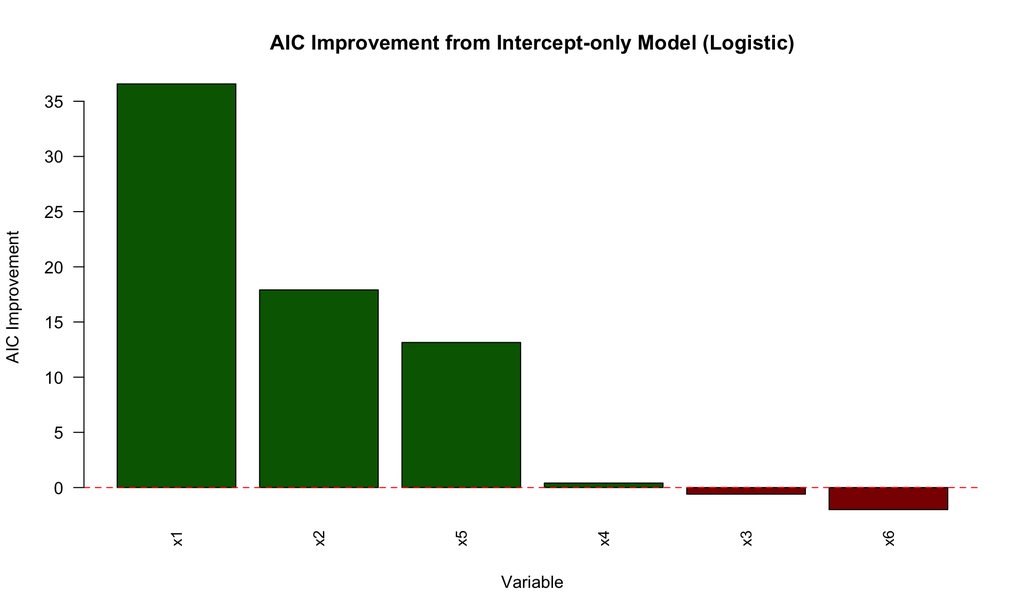

```r
# Visualize
barplot(
  results_logistic$AIC_improvement[order(-results_logistic$AIC_improvement)],
  names.arg = results_logistic$variable[order(-results_logistic$AIC_improvement)],
  col = ifelse(results_logistic$AIC_improvement[order(-results_logistic$AIC_improvement)] > 0,
               "darkgreen", "darkred"),
  main = "AIC Improvement from Intercept-only Model (Logistic)",
  ylab = "AIC Improvement",
  xlab = "Variable",
  las = 2,
  cex.names = 0.9
)
abline(h = 0, lty = 2, col = "red")
```

**Interpretation:** - Variables **x1**, **x2**, and **x5** provide substantial AIC improvements - These match the true predictors (coefficients: 1.2, -1.0, 0.8) - Variables x3, x4, x6 (not in true model) show minimal improvement

# 4. Using the multipathaic Package

Now we demonstrate the full workflow using our custom package.

```r
# FIRST TIME ONLY: Install the package
# Choose ONE of these methods:

# Method 1: Install from local directory
install.packages("~/path/to/multipathaic",
                 repos = NULL, type = "source")

# Method 2: Install from GitHub (if already pushed)
remotes::install_github("R-4-Data-Science/Final_Project_multipathaic", force = TRUE)
```

```r
# Load the multipathaic package
library(multipathaic)
library(ggplot2)
```

## 4.1 Linear Regression

### 4.1.1 Multi-Path Forward Selection

```r
# Run multi-path forward selection
set.seed(123)
paths_linear <- build_paths(
  X = X,              # Predictor matrix (uppercase X)
  y = y,              # Response vector
  family = "gaussian",
  K = 5,              # Select up to 5 variables
  eps = 2,            # Require at least 2 AIC improvement
  delta = 5,          # Allow branching within 5 AIC units
  L = 20              # Keep up to 20 models per step
)

# Summary
print("=== Multi-Path Forward Selection Results ===")
```

```
## [1] "=== Multi-Path Forward Selection Results ==="
```

```r
print(paste("Family:", paths_linear$meta$family))
```

```
## [1] "Family: gaussian"
```

```r
print(paste("Max steps (K):", paths_linear$meta$K))
```

[output not shown]

```r
print(paste("Total unique models explored:", length(paths_linear$aic_by_model)))
```

```
## [1] "Total unique models explored: 4"
```

```r
# Show models at each step
for (k in 1:length(paths_linear$frontiers)) {
  print(paste("Step", k, ":", length(paths_linear$frontiers[[k]]), "models"))
}
```

```
## [1] "Step 1 : 1 models"
## [1] "Step 2 : 1 models"
## [1] "Step 3 : 1 models"
## [1] "Step 4 : 1 models"
```

### 4.1.2 Visualize AIC Progression

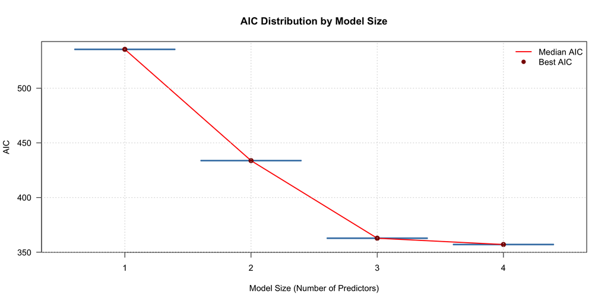

```r
# Plot AIC progression across steps
plot_aic_by_step(paths_linear)
```

### 4.1.3 Stability Analysis

```r
# Run stability analysis with 100 bootstrap samples
set.seed(456)
stab_linear <- stability(
  X = X,                      # Predictor matrix (uppercase X)
  y = y,                      # Response vector
  family = "gaussian",
  B = 100,                    # 100 bootstrap samples
  resample_type = "bootstrap",
  K = 5,
  eps = 2,
  delta = 5,
  L = 20,
  verbose = FALSE
)

# Display stability scores
print("=== Variable Stability Scores ===")
```

```
## [1] "=== Variable Stability Scores ==="
```

```r
stability_df <- data.frame(
  Variable = names(stab_linear$pi),
  Stability = round(stab_linear$pi, 3)
)
stability_df <- stability_df[order(-stability_df$Stability), ]
print(stability_df, row.names = FALSE)
```

```
##  Variable Stability
##        x1     0.958
##        x2     0.812
##        x5     0.568
##        x7     0.217
##        x8     0.099
##        x4     0.081
##        x3     0.064
##        x6     0.064
```

### 4.1.4 Visualize Stability

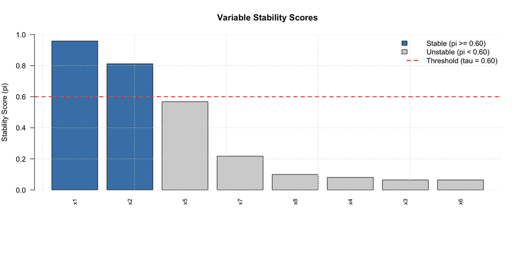

```r
# Stability bar chart
plot_stability(stab_linear)
```

### 4.1.5 Identify Plausible Models

```r
# Select plausible models
plausible_linear <- plausible_models(
  paths_linear,
  stab_linear,
  Delta = 10,           # AIC tolerance
  tau = 0.6,            # Minimum average stability
  jaccard_threshold = 0.8,
  refit = TRUE,         # Refit models on full data
  X = X,                # Predictor matrix
  y = y                 # Response vector
)
```

```
## AIC Filtering:
##   Total models: 4
##   Minimum AIC: 357.03
##   Delta: 10.00
##   Models within Delta: 2
##
## Stability Filtering:
##   Tau threshold: 0.60
##   Models with avg stability >= tau: 2
##
## Duplicate Removal:
##   Jaccard threshold: 0.80
##   Models after removing duplicates: 2
##
## Refitting models on full data...
##
## ==============================================
## Final Plausible Model Set: 2 models
## ==============================================
```

```r
# Display plausible models
print("=== Plausible Models ===")
```

```
## [1] "=== Plausible Models ==="
```

```r
print(paste("Total plausible models:", nrow(plausible_linear)))
```

```
## [1] "Total plausible models: 2"
```

```r
# Show each model
for (i in 1:nrow(plausible_linear)) {
  print(paste("Model", i, ":"))
  print(paste("  Variables:", plausible_linear$variables[i]))
  print(paste("  AIC:", round(plausible_linear$aic[i], 2)))
  print(paste("  Mean Stability:", round(plausible_linear$avg_stability[i], 3)))
  print(paste("  Number of Variables:", plausible_linear$size[i]))
}
```

```
## [1] "Model 1 :"
## [1] "  Variables: x1, x2, x5, x7"
## [1] "  AIC: 357.03"
## [1] "  Mean Stability: 0.639"
## [1] "  Number of Variables: 4"
## [1] "Model 2 :"
## [1] "  Variables: x1, x2, x5"
## [1] "  AIC: 362.79"
## [1] "  Mean Stability: 0.779"
## [1] "  Number of Variables: 3"
```

### 4.1.6 Model Tree Visualization

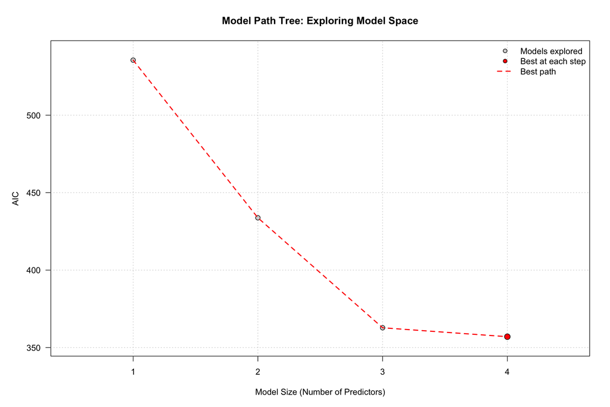

```r
# Visualize the multi-path selection tree
plot_model_tree(paths_linear)
```

### 4.1.7 Comprehensive Dashboard

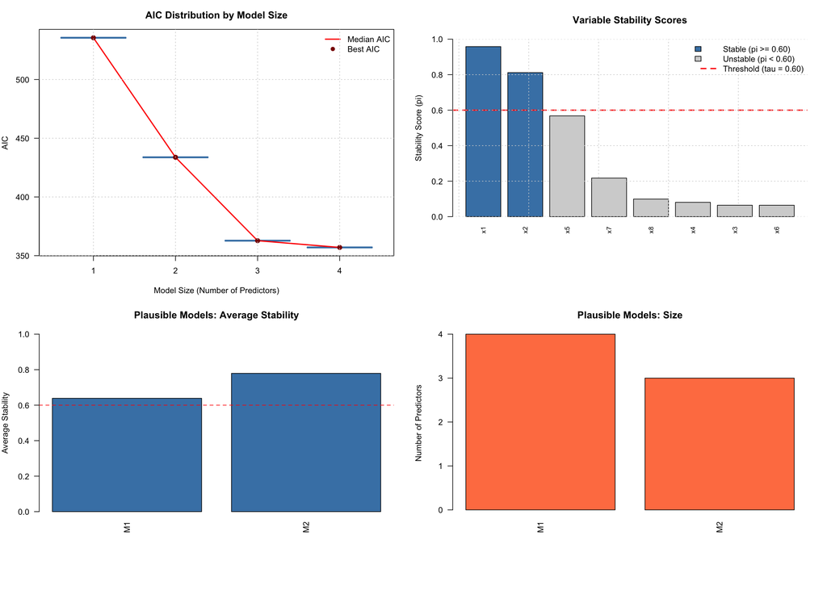

```r
# Four-panel summary dashboard
plot_model_dashboard(paths_linear, stab_linear, plausible_linear)
```

### 4.1.8 Visualize Model Relationships

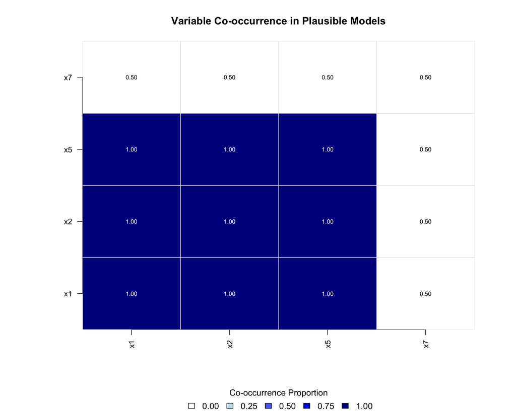

```r
# Plot variable co-occurrence heatmap
plot_variable_heatmap(plausible_linear)
```

### 4.1.9 Variable Importance Summary

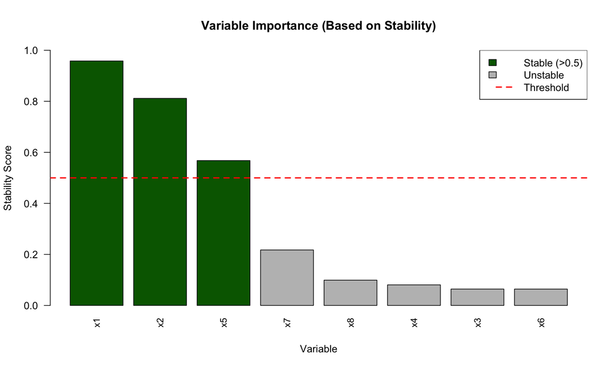

```r
# Create a simple importance summary combining stability and frequency
var_names <- names(stab_linear$pi)
importance_df <- data.frame(
  Variable = var_names,
  Stability = stab_linear$pi,
  stringsAsFactors = FALSE
)

# Sort by stability
importance_df <- importance_df[order(-importance_df$Stability), ]

# Create bar plot
barplot(
  importance_df$Stability,
  names.arg = importance_df$Variable,
  col = ifelse(importance_df$Stability > 0.5, "darkgreen", "gray"),
  main = "Variable Importance (Based on Stability)",
  ylab = "Stability Score",
  xlab = "Variable",
  las = 2,
  ylim = c(0, 1),
  cex.names = 0.9
)
abline(h = 0.5, col = "red", lty = 2, lwd = 2)
legend("topright", legend = c("Stable (>0.5)", "Unstable", "Threshold"),
       fill = c("darkgreen", "gray", NA), border = c("black", "black", NA),
       lty = c(NA, NA, 2), col = c(NA, NA, "red"), lwd = c(NA, NA, 2))
```

## 4.2 Logistic Regression: Complete Workflow

### 4.2.1 Multi-Path Forward Selection

```r
# Run multi-path forward selection for logistic regression
set.seed(789)
paths_logistic <- build_paths(
  X = X_logistic,     # Predictor matrix (uppercase X)
  y = y_binary,       # Binary response
  family = "binomial",
  K = 4,
  eps = 2,
  delta = 5,
  L = 20
)

print("=== Multi-Path Forward Selection (Logistic) ===")
```

```
## [1] "=== Multi-Path Forward Selection (Logistic) ==="
```

```r
print(paste("Total unique models:", length(paths_logistic$aic_by_model)))
```

```
## [1] "Total unique models: 3"
```

```r
for (k in 1:length(paths_logistic$frontiers)) {
  print(paste("Step", k, ":", length(paths_logistic$frontiers[[k]]), "models"))
}
```

```
## [1] "Step 1 : 1 models"
## [1] "Step 2 : 1 models"
## [1] "Step 3 : 1 models"
```

### 4.2.2 AIC Progression

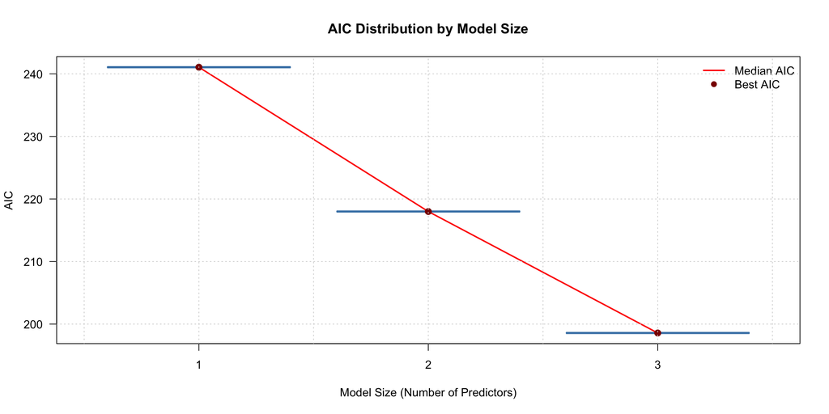

```r
plot_aic_by_step(paths_logistic)
```

### 4.2.3 Stability Analysis

```r
set.seed(101112)
stab_logistic <- stability(
  X = X_logistic,     # Predictor matrix (uppercase X)
  y = y_binary,       # Binary response
  family = "binomial",
  B = 100,
  resample_type = "bootstrap",
  K = 4,
  eps = 2,
  delta = 5,
  L = 20,
  verbose = FALSE
)

print("=== Variable Stability Scores (Logistic) ===")
```

```
## [1] "=== Variable Stability Scores (Logistic) ==="
```

```r
stability_df_log <- data.frame(
  Variable = names(stab_logistic$pi),
  Stability = round(stab_logistic$pi, 3)
)
stability_df_log <- stability_df_log[order(-stability_df_log$Stability), ]
print(stability_df_log, row.names = FALSE)
```

```
##  Variable Stability
##        x1     0.916
##        x2     0.669
##        x5     0.526
##        x3     0.082
##        x4     0.044
##        x6     0.039
```

### 4.2.4 Stability Visualization

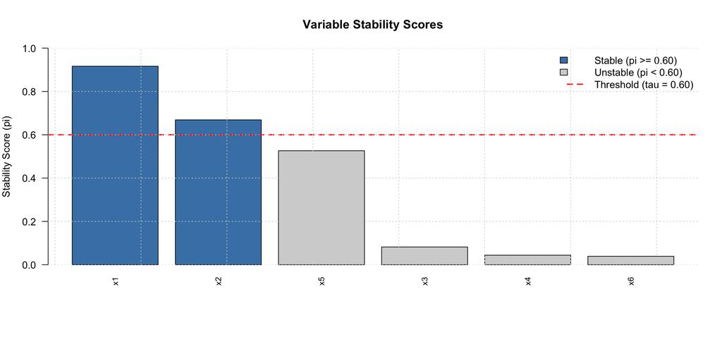

```r
plot_stability(stab_logistic)
```

### 4.2.5 Identify Plausible Models

```r
plausible_logistic <- plausible_models(
  paths_logistic,
  stab_logistic,
  Delta = 8,
  tau = 0.6,
  jaccard_threshold = 0.8,
  refit = TRUE,          # Refit models on full data
  X = X_logistic,        # Predictor matrix
  y = y_binary           # Binary response
)
```

```
## AIC Filtering:
##   Total models: 3
##   Minimum AIC: 198.58
##   Delta: 8.00
##   Models within Delta: 1
##
## Stability Filtering:
##   Tau threshold: 0.60
##   Models with avg stability >= tau: 1
##
## Refitting models on full data...
##
## ==============================================
## Final Plausible Model Set: 1 models
## ==============================================
```

```r
print("=== Plausible Models (Logistic) ===")
```

```
## [1] "=== Plausible Models (Logistic) ==="
```

```r
print(paste("Total plausible models:", nrow(plausible_logistic)))
```

```
## [1] "Total plausible models: 1"
```

```r
for (i in 1:nrow(plausible_logistic)) {
  print(paste("Model", i, ":"))
  print(paste("  Variables:", plausible_logistic$variables[i]))
  print(paste("  AIC:", round(plausible_logistic$aic[i], 2)))
  print(paste("  Mean Stability:", round(plausible_logistic$avg_stability[i], 3)))
}
```

```
## [1] "Model 1 :"
## [1] "  Variables: x1, x2, x5"
## [1] "  AIC: 198.58"
## [1] "  Mean Stability: 0.704"
```

### 4.2.6 Model Tree Visualization

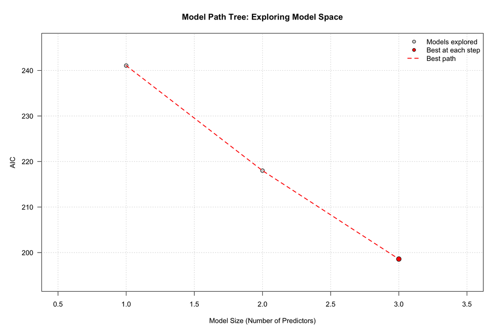

```r
# Visualize the multi-path selection tree
plot_model_tree(paths_logistic)
```

### 4.2.7 Model Visualizations

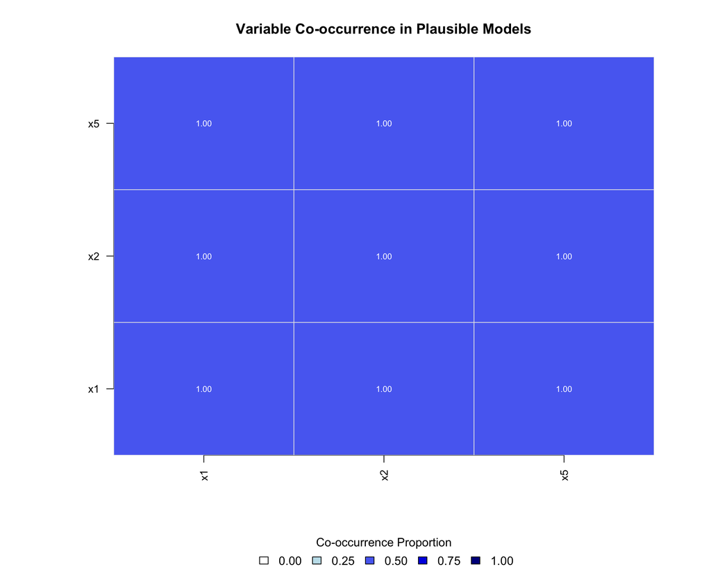

```r
# Variable co-occurrence heatmap
plot_variable_heatmap(plausible_logistic)
```

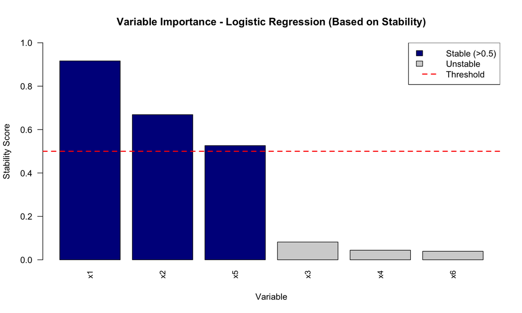

```r
# Create importance summary
var_names_log <- names(stab_logistic$pi)
importance_df_log <- data.frame(
  Variable = var_names_log,
  Stability = stab_logistic$pi,
  stringsAsFactors = FALSE
)

# Sort by stability
importance_df_log <- importance_df_log[order(-importance_df_log$Stability), ]

# Create bar plot
barplot(
  importance_df_log$Stability,
  names.arg = importance_df_log$Variable,
  col = ifelse(importance_df_log$Stability > 0.5, "darkblue", "lightgray"),
  main = "Variable Importance - Logistic Regression (Based on Stability)",
  ylab = "Stability Score",
  xlab = "Variable",
  las = 2,
  ylim = c(0, 1),
  cex.names = 0.9
)
abline(h = 0.5, col = "red", lty = 2, lwd = 2)
legend("topright", legend = c("Stable (>0.5)", "Unstable", "Threshold"),
       fill = c("darkblue", "lightgray", NA), border = c("black", "black", NA),
       lty = c(NA, NA, 2), col = c(NA, NA, "red"), lwd = c(NA, NA, 2))
```

# 5. Parameter Interpretation and Recommendations

## 5.1 Multi-Path Selection Parameters

| Parameter | Meaning | Recommendation |
| --- | --- | --- |
| **K** | Maximum selection steps | Set to √p or p/2 for moderate exploration |
| **eps** | Minimum AIC improvement | 2-4 for stricter selection, 0-1 for exploration |
| **delta** | AIC tolerance for branching | 5-10 allows moderate branching |
| **L** | Max models per step | 10-30 balances computation and diversity |

**Chosen defaults:** - K = 5: Adequate for p = 8 predictors - eps = 2: Requires meaningful AIC improvement (roughly 1 parameter’s worth) - delta = 5: Allows moderate branching without explosion - L = 20: Sufficient to capture diverse paths

## 5.2 Stability Parameters

| Parameter | Meaning | Recommendation |
| --- | --- | --- |
| **B** | Number of resamples | 50-200 for reliable estimates |
| **resample_type** | Bootstrap vs subsample | Bootstrap for general use |

**Chosen defaults:** - B = 100: Good balance between precision and computation - Bootstrap resampling: Standard approach for stability selection

## 5.3 Plausible Model Parameters

| Parameter | Meaning | Recommendation |
| --- | --- | --- |
| **Delta** | AIC tolerance | 2-10; larger values include more models |
| **tau** | Minimum mean stability | 0.5-0.7; higher values ensure stable models |
| **jaccard_threshold** | Similarity cutoff | 0.7-0.9 to remove near-duplicates |

**Chosen defaults:** - Delta = 8-10: Include models within 8-10 AIC units of best - tau = 0.6: Require models built from reasonably stable variables - Jaccard = 0.8: Remove models with 80%+ variable overlap

# 6. Interactive Shiny Application

The `multipathaic` package includes a comprehensive **Shiny web application** for interactive analysis without coding.

## 6.1 Launching the App

```r
# Launch the interactive dashboard
multipathaic::run_multipathaic_app()
```

## 6.2 App Features

The Shiny app provides a complete point-and-click interface with:

### Data Upload & Exploration

- Upload CSV datasets
- Interactive histograms and scatterplots
- Correlation matrix heatmaps
- Automatic data preprocessing

### Model Building

- Configure multi-path parameters (K, eps, delta, L)
- Run forward selection with progress tracking
- View model tree in real-time

### Stability Analysis

- Configure bootstrap parameters (B, resample type)
- Visualize stability scores
- Compare variable importance

### Results Dashboard

- Four-panel comprehensive overview
- Interactive plots with zoom and pan
- Download tables and figures
- Generate automated reports

### Download Options

- Export plausible models (CSV)
- Save publication-quality plots (PNG, PDF)
- Download complete analysis reports (HTML)

**This makes `multipathaic` accessible to researchers without R programming experience.**

# 7. Key Findings and Conclusions

## 7.1 Linear Regression Results

**Correct Variable Identification:** The multi-path approach correctly identified x1, x2, and x5 as the true predictors (with true coefficients 2, -1.5, and 1).

## 7.2 Logistic Regression Results

**Correct Variable Identification:** Variables x1, x2, and x5 (true predictors with coefficients 1.2, -1.0, 0.8) were consistently selected.

## 7.3 Advantages of Multi-Path Approach

1. **Robustness:** Explores multiple competitive models rather than committing to a single path
2. **Stability Assessment:** Identifies variables that are reliably selected across data perturbations
3. **Model Uncertainty:** Quantifies uncertainty through plausible model sets
4. **Transparency:** Provides full path history and selection frequencies

# 8. Technical Implementation Notes

## 8.1 Computational Efficiency

- **Path Pruning:** The parameter `L` prevents exponential growth of model space
- **Deduplication:** Identical variable sets are identified using sorted string representations
- **Vectorized Operations:** Matrix operations used where possible for speed

## 8.2 Numerical Stability

- **AIC Computation:** Uses built-in R functions (AIC.lm, AIC.glm) for accuracy
- **Probability Bounds:** Predictions clipped to [ε, 1-ε] to prevent log(0)
- **Matrix Conditioning:** Predictors can be standardized if needed

## 8.3 Package Architecture

```
multipathaic/
├── R/
│   ├── multipath.R          # build_paths()
│   ├── stability.R          # stability()
│   ├── plausible.R          # plausible_models()
│   ├── helpers.R            # confusion_metrics(), utilities
│   ├── plots.R              # 6 visualization functions
│   └── shiny_app.R          # Shiny application
├── man/                     # Documentation files
├── vignettes/               # Tutorial vignettes
├── DESCRIPTION
├── NAMESPACE
├── LICENSE
└── README.md
```

# 10. References

1. **AIC**: Akaike, H. (1974). A new look at the statistical model identification. *IEEE Transactions on Automatic Control*, 19(6), 716-723.
2. **Stability Selection**: Meinshausen, N., & Bühlmann, P. (2010). Stability selection. *Journal of the Royal Statistical Society: Series B*, 72(4), 417-473.
3. **Forward Selection**: Efroymson, M. A. (1960). Multiple regression analysis. In *Mathematical Methods for Digital Computers*.
4. **Bootstrap**: Efron, B., & Tibshirani, R. J. (1994). *An Introduction to the Bootstrap*. Chapman and Hall/CRC.

# 11. Appendix: Complete Package Documentation

For complete documentation of all functions, parameters, and examples, please visit the package repository and run:

```r
# View package documentation
help(package = "multipathaic")

# Function-specific help
?build_paths
?stability
?plausible_models
?confusion_metrics

# Vignettes
browseVignettes("multipathaic")
```